# Homework 4 Adv Ts

Emanuele Ceglia, Paolo Lorusso

2022-06-07

```r
tickers <- c("^GSPC")
start_stream <- '2015-01-01'
end_stream = Sys.Date()

getSymbols(tickers, src = 'yahoo', from = start_stream, to=end_stream)

GSPC_week <- to.weekly(GSPC)
GSPC_week_rtn <- diff(log(GSPC_week$GSPC.Close))
GSPC_week_rtn <- na.omit(GSPC_week_rtn)
```

Below we can see the price chart of the Standard and Poor 500, is a stock market index tracking the performance of 500 large companies listed on stock exchanges in the United States. It is one of the most commonly followed equity indices.  
According to the definition of volatility clustering: *“Large changes tend to be followed by large changes, and small changes tend to be followed by small changes.”* We have underlined some periods of high volatility, often characterized by negative trends, using vertical lines.

[interactive chart not shown]

For our analysis we have to use log returns because they satisfy some stylized facts.  
1) Returns are either serially uncorrelated or weakly dependent over time.  
2) Returns are not independent: square and absolute returns show correlation (even at high lags)  
3) Volatility is an important feature of asset returns. It changes slowly over time and thus it shows up in the ACF of absolute or squared returns.  
4) Financial time series exhibit volatility clustering. The conditional variance is time varying and periods where volatility is low are alternated by periods of high volatility.  
We can observe the first two facts below

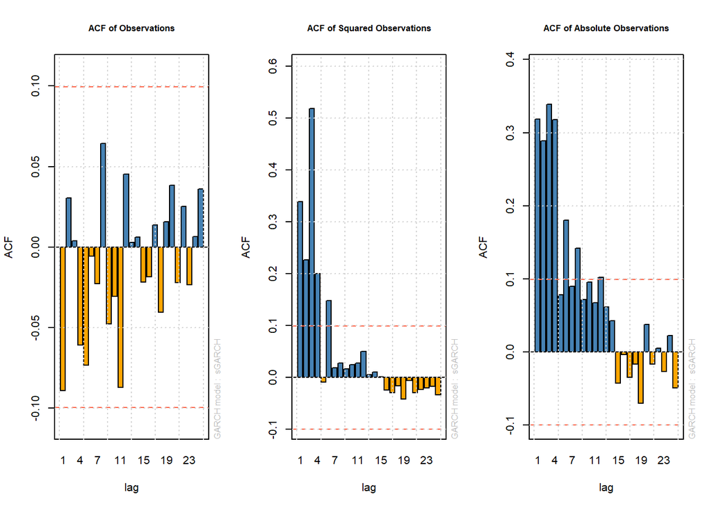

In the first graph we can see the autocorrelation function of log returns, they are significantly uncorrelated.  
While in the second and third graph we can see the acf of squared and absolute log returns, as told in 2) they are not independent, in fact there is a positive and significant correlation from lag of order one till 6/10

Moreover, using log returns: log(Pt/Pt-1) the conditional and unconditional mean return is zero so our series becomes yt = εt = σt|t−1*zt, where Zt ∼ NID(0, 1)  
hence, yt is a martingale difference sequence and therefore  
- E(yt) = 0.  
- E(y<sup>2</sup>t|Ft−1) = E(σ<sup>2</sup>t|t−1z<sup>2</sup>t|Ft−1) = σ<sup>2</sup>t|t−1E(z<sup>2</sup>t|Ft−1) = σ<sup>2</sup>t|t−1E(z<sup>2</sup>t) = σ<sup>2</sup>t|t−1 (as shown in volatility chart)

[interactive chart not shown]

For a better volatility clustering is usefull the chart of variance, in fact it’s easy to see periods of high volatility between the vertical lines

[interactive chart not shown]

Define GARCH(1,1) model with **normal distribution assumpution for errors**

```r
s <- ugarchspec(mean.model = list(armaOrder = c(0,0)),
                variance.model = list(model = 'sGARCH'),
                distribution.model = 'norm')

m <- ugarchfit(data = GSPC_week_rtn, spec = s)
```

```
##  [1] "*---------------------------------*"
##  [2] "*          GARCH Model Fit        *"
##  [3] "*---------------------------------*"
##  [4] ""
##  [5] "Conditional Variance Dynamics \t"
##  [6] "-----------------------------------"
##  [7] "GARCH Model\t: sGARCH(1,1)"
##  [8] "Mean Model\t: ARFIMA(0,0,0)"
##  [9] "Distribution\t: norm "
## [10] ""
## [11] "Optimal Parameters"
## [12] "------------------------------------"
## [13] "        Estimate  Std. Error  t value Pr(>|t|)"
## [14] "mu      0.002817    0.000756   3.7248 0.000195"
## [15] "omega   0.000030    0.000012   2.5449 0.010931"
## [16] "alpha1  0.356549    0.067431   5.2876 0.000000"
## [17] "beta1   0.642451    0.051666  12.4347 0.000000"
## [18] ""
```

```
##  [1] "Weighted Ljung-Box Test on Standardized Residuals"
##  [2] "------------------------------------"
##  [3] "                        statistic p-value"
##  [4] "Lag[1]                      1.725  0.1890"
##  [5] "Lag[2*(p+q)+(p+q)-1][2]     1.776  0.3028"
##  [6] "Lag[4*(p+q)+(p+q)-1][5]     2.245  0.5618"
##  [7] "d.o.f=0"
##  [8] "H0 : No serial correlation"
##  [9] ""
## [10] "Weighted Ljung-Box Test on Standardized Squared Residuals"
## [11] "------------------------------------"
## [12] "                        statistic p-value"
## [13] "Lag[1]                     0.4003  0.5269"
## [14] "Lag[2*(p+q)+(p+q)-1][5]    1.4384  0.7550"
## [15] "Lag[4*(p+q)+(p+q)-1][9]    2.1328  0.8886"
## [16] "d.o.f=2"
```

We can see it also in these two graphs.

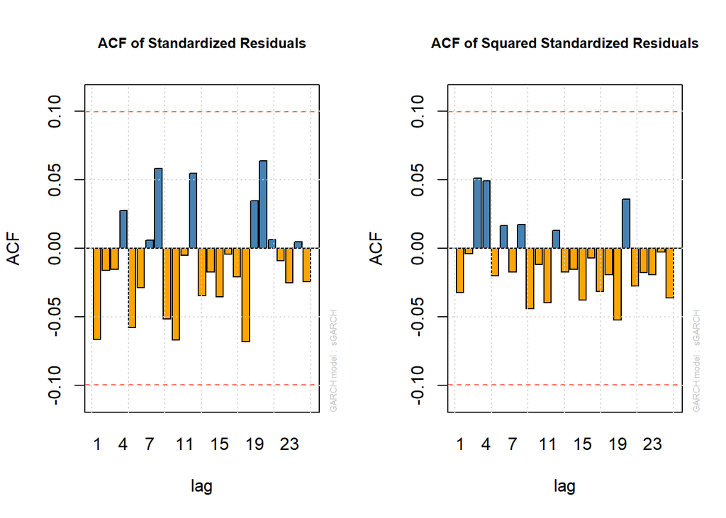

```
## Skweness: -1.119386    Kurtosis: 9.243577
```

```
## [1] "Adjusted Pearson Goodness-of-Fit Test:"
## [2] "------------------------------------"
## [3] "  group statistic p-value(g-1)"
## [4] "1    20     31.48      0.03569"
## [5] "2    30     36.64      0.15568"
## [6] "3    40     50.56      0.10173"
## [7] "4    50     50.92      0.39804"
```

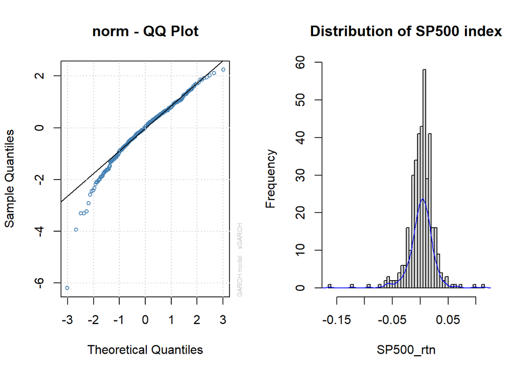

The normality assumption for errors is more appropriate for analyze periods of economic stability, because in these periods the stock market tends to be less volatile.  
In our case the time period considered starts in 2015 and ends today, as shown in the volatility clustering we have found some periods of high stress. These periods are generated by exogenous factors. In particular:  
in the second period investors feared a central bank ready to tighten monetary policy, a slowing economy, and an intensifying trade war between the U.S. and China;  
in the third period there was the outbreak of Covid-19;  
while in the fourth period we can see the effects of the war between Russia and Ukraine.  
All these events underline the fact that we are analyzing a period of economic instability, with frequent market drops which increase market volatility.  
So, we can try a different distribution for innovation, and keeping in mind the values of skweness and kurtosis, our proposal is to use a skew Student-t distribution.

Define GARCH(1,1) model with **Skew Student-t distribution assumpution for errors**

```r
s <- ugarchspec(mean.model = list(armaOrder = c(0,0)),
                variance.model = list(model = 'sGARCH'),
                distribution.model = 'sstd')

m <- ugarchfit(data = GSPC_week_rtn, spec = s)
```

```
##  [1] "*---------------------------------*"
##  [2] "*          GARCH Model Fit        *"
##  [3] "*---------------------------------*"
##  [4] ""
##  [5] "Conditional Variance Dynamics \t"
##  [6] "-----------------------------------"
##  [7] "GARCH Model\t: sGARCH(1,1)"
##  [8] "Mean Model\t: ARFIMA(0,0,0)"
##  [9] "Distribution\t: sstd "
## [10] ""
## [11] "Optimal Parameters"
## [12] "------------------------------------"
## [13] "        Estimate  Std. Error  t value Pr(>|t|)"
## [14] "mu      0.002782    0.000735   3.7834 0.000155"
## [15] "omega   0.000026    0.000011   2.3257 0.020035"
## [16] "alpha1  0.318781    0.082937   3.8436 0.000121"
## [17] "beta1   0.667528    0.066135  10.0935 0.000000"
## [18] "skew    0.786021    0.055935  14.0523 0.000000"
## [19] "shape   6.228602    1.884882   3.3045 0.000951"
```

Also in this case, we can accept that our parameters ar all significant.

```
##  [1] "Weighted Ljung-Box Test on Standardized Residuals"
##  [2] "------------------------------------"
##  [3] "                        statistic p-value"
##  [4] "Lag[1]                      1.716  0.1903"
##  [5] "Lag[2*(p+q)+(p+q)-1][2]     1.772  0.3035"
##  [6] "Lag[4*(p+q)+(p+q)-1][5]     2.224  0.5665"
##  [7] "d.o.f=0"
##  [8] "H0 : No serial correlation"
##  [9] ""
## [10] "Weighted Ljung-Box Test on Standardized Squared Residuals"
## [11] "------------------------------------"
## [12] "                        statistic p-value"
## [13] "Lag[1]                     0.3146  0.5749"
## [14] "Lag[2*(p+q)+(p+q)-1][5]    1.4807  0.7446"
## [15] "Lag[4*(p+q)+(p+q)-1][9]    2.2231  0.8768"
## [16] "d.o.f=2"
```

There is no serial correlation, so our residuals follow a white noise process

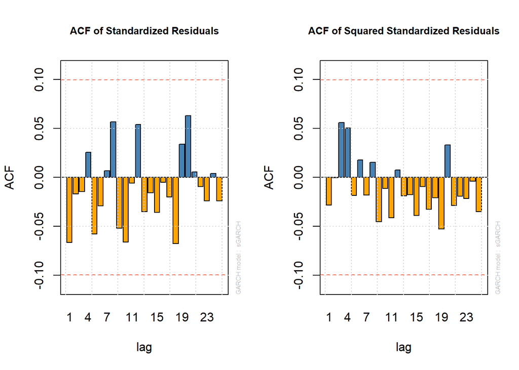

But the most interesting part is shown in the final test. Now we can see that our assumption of a skew Student-t distribution is very accurate.

```
## [1] "Adjusted Pearson Goodness-of-Fit Test:"
## [2] "------------------------------------"
## [3] "  group statistic p-value(g-1)"
## [4] "1    20     13.55       0.8095"
## [5] "2    30     17.31       0.9572"
## [6] "3    40     24.58       0.9653"
## [7] "4    50     38.55       0.8585"
```

Now our sample quantiles overlap the theoretical quantiles more accurately than before.  
We can see an outlier on the bottom left side, we are preatty sure that is related to the 20 march 2020, on that day the SP500, due to the Covid-19 outbreak, plummed to 2.300$ making a negative performance of 30%.

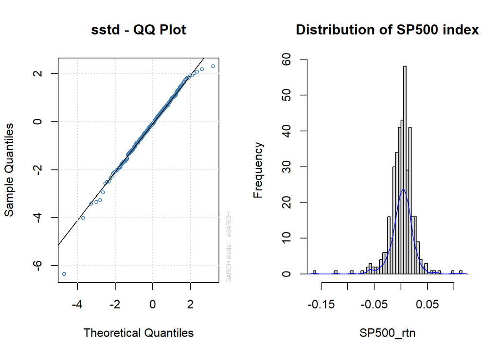

Now we want to introduce a new assumption based on the empirical data:

[interactive chart not shown]

As you can see in the above graph, markets drop quickly but recover the loss in much more time.  
This fact leads us to think that when the market decreases, lose a lot in a short time, so in those days/weeks the volatility is very high. While to return at the same maximum level need more positive days/weeks, so positive increments are smaller than negative ones.

At this point we can introduce the GJR-GARCH model, this model introduce a new parameter called ‘gamma’, this parameter is identical to alpha but it multiplies a dummy variable which is equal to zero when the return is positive while it is equal to one when the return is negative.  
So we are trying to model the variance during negative periods in a better way.

Define a GJR-GARCH(1,1) model with **Skew Student-t distribution assumpution for errors**  
We have decided to keep the sstd assumption for innovations.

```r
s <- ugarchspec(mean.model = list(armaOrder = c(0,0)),
                variance.model = list(model = 'gjrGARCH', garchOrder = c(1,1)),
                distribution.model = 'sstd')

m <- ugarchfit(data = GSPC_week_rtn, spec = s)
```

```
##  [1] "*---------------------------------*"
##  [2] "*          GARCH Model Fit        *"
##  [3] "*---------------------------------*"
##  [4] ""
##  [5] "Conditional Variance Dynamics \t"
##  [6] "-----------------------------------"
##  [7] "GARCH Model\t: gjrGARCH(1,1)"
##  [8] "Mean Model\t: ARFIMA(0,0,0)"
##  [9] "Distribution\t: sstd "
## [10] ""
## [11] "Optimal Parameters"
## [12] "------------------------------------"
## [13] "        Estimate  Std. Error  t value Pr(>|t|)"
## [14] "mu      0.001551    0.000768  2.01917 0.043470"
## [15] "omega   0.000037    0.000012  3.12562 0.001774"
## [16] "alpha1  0.004252    0.065149  0.06527 0.947959"
## [17] "beta1   0.677619    0.056168 12.06406 0.000000"
## [18] "gamma1  0.578533    0.162029  3.57054 0.000356"
## [19] "skew    0.695679    0.055898 12.44547 0.000000"
## [20] "shape   6.438438    1.979195  3.25306 0.001142"
```

As we can see, alpha is irrelevant but we want to focus our attention on gamma, as told before in this model we are trying to analyze variance during negative returns, and as we can see the p-value of this parameter is near to zero so we can conclude that it is significant.

```
##  [1] "Weighted Ljung-Box Test on Standardized Residuals"
##  [2] "------------------------------------"
##  [3] "                        statistic p-value"
##  [4] "Lag[1]                      1.204  0.2724"
##  [5] "Lag[2*(p+q)+(p+q)-1][2]     1.237  0.4272"
##  [6] "Lag[4*(p+q)+(p+q)-1][5]     1.597  0.7160"
##  [7] "d.o.f=0"
##  [8] "H0 : No serial correlation"
##  [9] ""
## [10] "Weighted Ljung-Box Test on Standardized Squared Residuals"
## [11] "------------------------------------"
## [12] "                        statistic p-value"
## [13] "Lag[1]                    0.03069  0.8609"
## [14] "Lag[2*(p+q)+(p+q)-1][5]   0.76319  0.9105"
## [15] "Lag[4*(p+q)+(p+q)-1][9]   1.23263  0.9745"
## [16] "d.o.f=2"
```

Residuals follow a white noise process.

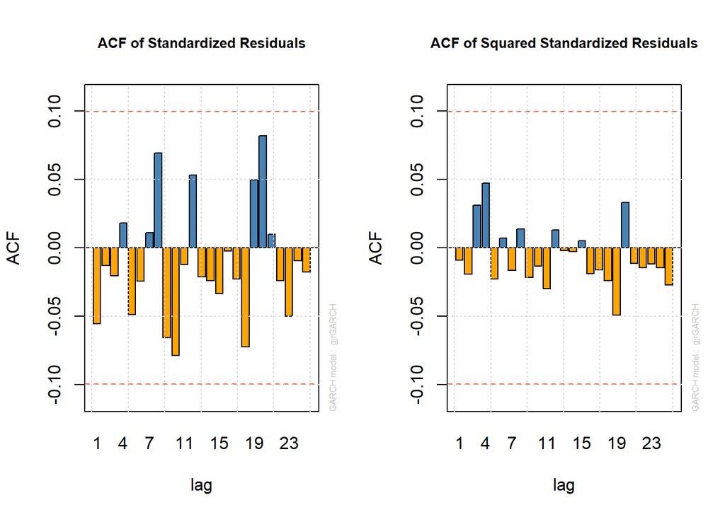

```
## [1] "Adjusted Pearson Goodness-of-Fit Test:"
## [2] "------------------------------------"
## [3] "  group statistic p-value(g-1)"
## [4] "1    20     5.711       0.9985"
## [5] "2    30    12.515       0.9967"
## [6] "3    40    20.454       0.9937"
## [7] "4    50    20.505       0.9999"
```

To conclude we can see how good fit the assumption of a Skew Student-t distribution for innovations in this model.

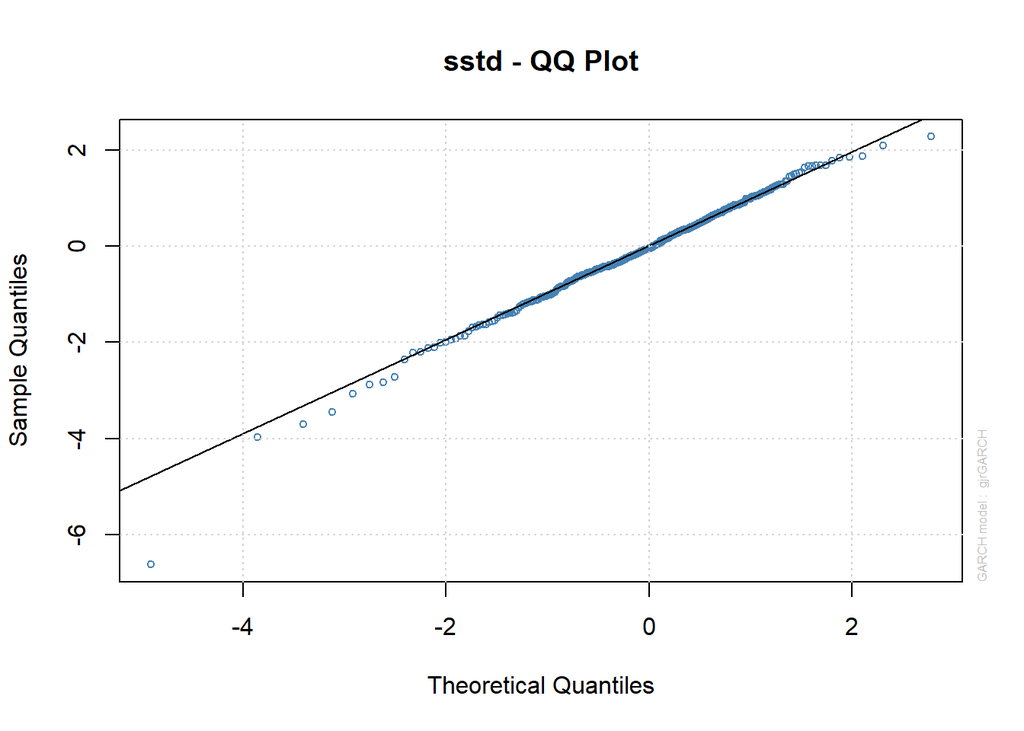

To conclude, we have seen three models, first and second are based on simple GARCH(p,q) while the third is based on GJR-GARCH(p,q).  
We set the parameters ‘p’ and ‘q’ equal to one, but, for a deeper analysis we could try different combinations like GARCH(1,2) or GARCH(2,1) etc. and compare these models using the AIC information.  
It might also be interesting to try a train/test approach, in order to make a prediction analysis.